# 16.2_multi_class_classification

```python
import pandas as pd
import numpy as np
import matplotlib.pyplot as plt
% matplotlib inline
import seaborn as sns
from sklearn.base import BaseEstimator, TransformerMixin
from sklearn.pipeline import Pipeline
from sklearn.preprocessing import MinMaxScaler
from sklearn.model_selection import GridSearchCV

plt.rcParams['axes.labelsize'] = 14
plt.rcParams['xtick.labelsize'] = 12
plt.rcParams['ytick.labelsize'] = 12
import warnings
warnings.filterwarnings('ignore')

import random
random.seed(10)
```

```python
digit_dataset = pd.read_csv('../data/digit_recognizer_train.csv')
```

```python
digit_X = digit_dataset.iloc[:, 1:]
digit_y = digit_dataset['label']
```

```python
# By default train_test_split does STRATIFIED split based on label (y-value).
from sklearn.model_selection import train_test_split
digit_X_train, digit_X_test, digit_y_train, digit_y_test = train_test_split(digit_X, digit_y, test_size=0.2)
```

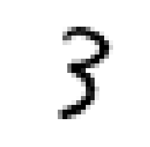

```python
some_digit = digit_X_train.iloc[6735]
some_digit_image = some_digit.reshape(28, 28)
from  matplotlib.cm import  binary
plt.imshow(some_digit_image, cmap = binary,
           interpolation="nearest")
plt.axis("off")
plt.show()
```

# Multiclass Classification

- Multiclass classifiers can distinguish between more than two classes.
- By default some algorithms such as "Random Forest Classifier", "Naive Bayes Classifier" can handle multiclass classication.
- Some algorithms such as "Support Vector Machine(SVM)", "Linear Classifiers" cannot hanlde multiclass. There are some methods such as One-Versus-All, One-Versus-One to handle multiclass classification using these algorithms.
- When we use multiclass incapable algorithms, scikit-Learn detects and most of the times it applies One-Vs-All automatically. For SVM it applies One-Vs-One as it scales poorly with size of the train set. ### One-Versus-All : Create one binary classifier for each class ("0-vs-other", 1-vs-other", ..., "9-vs-other"), take decision scores from each classifier. select the class whose classifier outputs the highest score. ### One-Versus-One : Train a binary class for each pair of classes ("0-vs-1", "0-vs-2", ..., "0-vs-9", "1-vs-0", "1-vs-2", ..., "1-vs-9", ...., "9-vs-8"). If there are N classes, we need to train N*(N - 1)/2 number of classifiers. When we have to classify, need to run all these classifiers and see which one gets the highest decision score.

```python
pipeline_min_max_scale = Pipeline([
    ('minMaxScaler', MinMaxScaler())
])
```

```python
digit_X_train = pipeline_min_max_scale.fit_transform(digit_X_train)
```

```python
from sklearn.linear_model import SGDClassifier

sgd_clf = SGDClassifier(random_state=42, loss='log')
sgd_clf.fit(digit_X_train, digit_y_train)
```

```
SGDClassifier(alpha=0.0001, average=False, class_weight=None, epsilon=0.1,
       eta0=0.0, fit_intercept=True, l1_ratio=0.15,
       learning_rate='optimal', loss='log', n_iter=5, n_jobs=1,
       penalty='l2', power_t=0.5, random_state=42, shuffle=True, verbose=0,
       warm_start=False)
```

#### model.predict() vs model.predict_proba():

- predict will predict the taget value, where as predict_proba will give the probabilities of each class.

```python
np_some_digit = digit_X_train[6735]
sgd_clf.predict(np_some_digit)
```

```
array([3], dtype=int64)
```

```python
sgd_clf.predict_proba(np_some_digit)
```

```
array([[  9.74098522e-18,   1.77628726e-05,   1.32276462e-03,
          6.78633293e-01,   1.27465367e-04,   4.80740397e-05,
          1.97625786e-09,   2.58148834e-05,   1.12578388e-04,
          3.19712245e-01]])
```

- When we call decision function on classifier with "some_digit", we get 10 scores instead of one. Scikit-learn understood that we are trying to use linear classifer to do multiclassification, hence it applied One-Vs-All strategy and gave us the scores.

```python
some_digit_scores = sgd_clf.decision_function(np_some_digit)
```

```python
some_digit_scores
```

```
array([[-38.89005869, -10.65824586,  -6.34614865,   2.17560483,
         -8.68736645,  -9.6625739 , -19.76193003, -10.28439447,
         -8.81158109,  -0.31015828]])
```

```python
# np.argmax returns the index of the maximum value
np.argmax(some_digit_scores)
```

```
3
```

```python
sgd_clf.classes_
```

```
array([0, 1, 2, 3, 4, 5, 6, 7, 8, 9], dtype=int64)
```

```python
sgd_clf.classes_[3]
```

```
3
```

## One-Vs-All

```python
from sklearn.multiclass import OneVsRestClassifier
onevsall = OneVsRestClassifier(SGDClassifier(random_state=32, loss='log'))
onevsall.fit(digit_X_train, digit_y_train)
```

```
OneVsRestClassifier(estimator=SGDClassifier(alpha=0.0001, average=False, class_weight=None, epsilon=0.1,
       eta0=0.0, fit_intercept=True, l1_ratio=0.15,
       learning_rate='optimal', loss='log', n_iter=5, n_jobs=1,
       penalty='l2', power_t=0.5, random_state=32, shuffle=True, verbose=0,
       warm_start=False),
          n_jobs=1)
```

```python
len(onevsall.estimators_)
```

```
10
```

```python
onevsall.predict_proba(np_some_digit)
```

```
array([[  1.32465493e-14,   8.28462341e-04,   1.64397048e-02,
          9.04430942e-01,   2.57373558e-04,   1.90081623e-02,
          3.84193764e-11,   1.74837586e-05,   1.04756875e-09,
          5.90178696e-02]])
```

```python
onevsall.decision_function(np_some_digit)
```

```
array([[-31.95939523,  -7.0994699 ,  -4.09590808,   2.20279116,
         -8.26908163,  -3.94813579, -23.98681511, -10.9585767 ,
        -20.68114975,  -2.77371237]])
```